# Spatial Econometrics & Outlook

Anne Stroppe, Dennis Abel

2026-06-12

## Now

| Day | Time | Title |
| --- | --- | --- |
| June 11 | 10:00-11:30 | Introduction |
| June 11 | 11:30-11:45 | Coffee Break |
| June 11 | 11:45-13:00 | Data Formats |
| June 11 | 13:00-14:00 | Lunch Break |
| June 11 | 14:00-15:30 | Mapping |
| June 11 | 15:30-15:45 | Coffee Break |
| June 11 | 15:45-17:00 | Spatial Wrangling |
| June 12 | 10:00-11:30 | Spatial Wrangling |
| June 12 | 11:30-11:45 | Coffee Break |
| June 12 | 11:45-13:00 | Geocoding, Proximity & Spatial Alignment |
| June 12 | 13:00-14:00 | Lunch Break |
| June 12 | 14:00-15:30 | Spatial Analysis |
| June 12 | 15:30-15:45 | Coffee Break |
| June 12 | 15:45-17:00 | Spatial Econometrics & Outlook |

## What are spatial econometrics?

Classic econometrics:

- Using statistics to model (complex) theories, esp. causal thinking
- As default, we think about regression analysis

One core assumption: Observations are independent of each other. However, we just learnt that is often not the case.

> **Where does spatial dependence and spatial processes enter our models and affect our outcome of interest?**

## Is it meaningful or just nuisances?

Space can be important in our analysis in two ways.

- It’s meaningful in our theory, and we thus interpret it accordingly after estimation
- It can distort our empirical estimates, producing bias, inconsistency, and inefficiency

We can address these different perspectives in our analysis with spatial econometric methods.

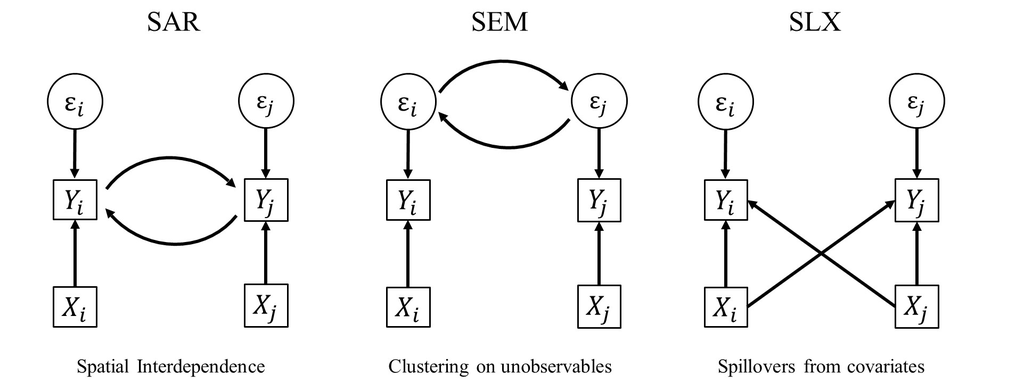

## Spatial Diffusion

- $y_i$ affects $y_j$ through $w_{ij}$
- $y_j$ affects $y_i$ through $w_{ji}$
- endogenous by design!
- Examples:
  - tax competition: if a state cuts corporate tax, neighbours respond by cutting theirs too
  - civil war onset: conflict in one country raises the probability of onset in neighbours

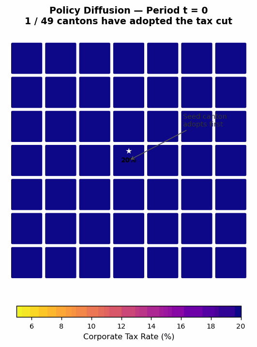

## Spatial Spill-Over

- $x_i$ affects $y_j$ through $w_{ij}$
- $x_j$ affects $y_i$ through $w_{ij}$
- Examples:
  - trade and export: a neighbour region’s GDP (their X) raises your export volumes or wages (your Y)
  - crime displacement: increased policing in one neighbourhood raises crime in your neighbourhood, as criminals relocate

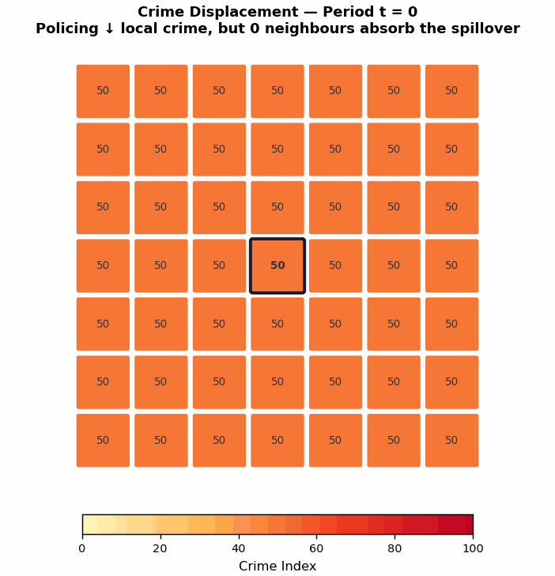

## Formulas…

Linear Regression:
$$\small Y = X\beta + \epsilon$$

Spatial Lag Y / Spatial Autoregressive Model (SAR, Diffusion):
$$\small Y = \rho WY + X\beta + \epsilon$$

Spatial Lag X Model (SLX, Spillover):
$$\small Y = X\beta + WX\theta + \epsilon$$

Spatial Error Model (SEM):
$$\small Y = X\beta + u$$
$$\small u = \lambda Wu + \epsilon$$

## Flavors and extensions

But what if….

- … you have interdependence and spillovers in covariates?
- … spillovers and clustering in errors?
- … interdependence and clustering in errors?
- … everything is related with everything?

[figure not shown]

## Flavors and extensions

**Spatial Durbin Model**

$$Y = \rho WY + X\beta + WX\theta + \epsilon$$

**Spatial Durbin Error Model**

$$Y = X\beta + WX\theta + u$$
$$u = \lambda Wu + \epsilon$$

**Combined Spatial Autocorrelation Model**

$$Y = \rho WY + X\beta + u$$
$$u = \lambda Wu + \epsilon$$

**Manski Model**

$$Y = \rho WY + WX\theta + X\beta + u$$
$$u = \lambda Wu + \epsilon$$

## Which model to choose?

[interactive chart not shown]

## Intermediate summary

There are a lot of models you could estimate to *explain* spatial autocorrelation. And there’s a vast body of literature on the best choice for which application. Important for us: theory-grounded reasoning for the underlying data generating process.

Getting this wrong has real consequences:

- Misspecifying SAR as OLS → biased β (omitted variable: Wy)
- Misspecifying SEM as OLS → correct β, wrong inference (deflated SEs)
- Misspecifying SEM as SAR → spurious diffusion, inefficient β
- Misspecifying SAR as SLX → underestimates spillovers (captures first-order neighbour effect)

We’d explicitly like to recommend the work of [Tobias Rüttenauer](https://ruettenauer.github.io/publication/) for us social scientists. [Here](https://ruettenauer.github.io/Geodata_Spatial_Regression) are some really nice workshop materials.

## ‘Research’ question and data

We will use the same example as in the previous session. But this time, we will test if one of our spatial regression models helps further investigate the data generation process. We may ask:

1. Do immigrant shares affect CDU voting shares within voting districts?
2. Do immigrant shares affect CDU voting shares between neighborhoods? (=spillover)
3. Do CDU voting shares affect CDU voting shares between neighborhoods? (=diffusion)

Controlling inhabitant numbers within the voting districts might also be a good idea.

## Linear regression

```r
linear_regression <-
  lm(cdu_share ~ immigrant_share + inhabitants, data = election_results)

summary(linear_regression)
```

```
Call:
lm(formula = cdu_share ~ immigrant_share + inhabitants, data = election_results)

Residuals:
     Min       1Q   Median       3Q      Max
-15.0379  -3.3415  -0.3242   3.2834  24.7445

Coefficients:
                 Estimate Std. Error t value Pr(>|t|)
(Intercept)     28.066680   1.050168  26.726  < 2e-16 ***
immigrant_share -0.077070   0.014311  -5.385 1.08e-07 ***
inhabitants     -0.083491   0.004932 -16.928  < 2e-16 ***
---
Signif. codes:  0 '***' 0.001 '**' 0.01 '*' 0.05 '.' 0.1 ' ' 1

Residual standard error: 5.174 on 540 degrees of freedom
Multiple R-squared:  0.409, Adjusted R-squared:  0.4068
F-statistic: 186.8 on 2 and 540 DF,  p-value: < 2.2e-16
```

## Now we need a spatial weight

Once again, we have to construct a spatial weight as in the analysis of spatial autocorrelation to estimate a spatial regression. In fact, we’ll use the same approach as before.

```r
queen_neighborhoods <- spdep::poly2nb(election_results, queen = TRUE)

queen_W <- spdep::nb2listw(queen_neighborhoods, style = "W")
```

## Spatial Error Model

```r
spatial_error_model <-
  spatialreg::errorsarlm(
    cdu_share ~ immigrant_share + inhabitants,
    data = election_results, listw = queen_W)

summary(spatial_error_model)
```

```
Call:spatialreg::errorsarlm(formula = cdu_share ~ immigrant_share +
    inhabitants, data = election_results, listw = queen_W)

Residuals:
      Min        1Q    Median        3Q       Max
-10.09970  -2.33331  -0.33229   1.99941  24.40641

Type: error
Coefficients: (asymptotic standard errors)
                  Estimate Std. Error z value  Pr(>|z|)
(Intercept)     21.8137216  1.1589897 18.8213 < 2.2e-16
immigrant_share -0.0307508  0.0117756 -2.6114  0.009017
inhabitants     -0.0293662  0.0047947 -6.1248 9.082e-10

Lambda: 0.7907, LR test value: 270.73, p-value: < 2.22e-16
Asymptotic standard error: 0.030988
    z-value: 25.516, p-value: < 2.22e-16
Wald statistic: 651.08, p-value: < 2.22e-16

Log likelihood: -1526.079 for error model
ML residual variance (sigma squared): 13.821, (sigma: 3.7177)
Number of observations: 543
Number of parameters estimated: 5
AIC: 3062.2, (AIC for lm: 3330.9)
```

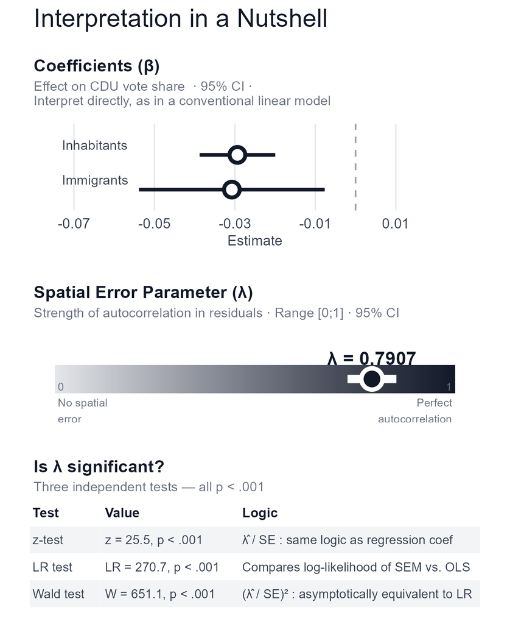

## Spatial Lag X Model

```r
spatial_lag_x_model <-
  spatialreg::lmSLX(
    cdu_share ~ immigrant_share + inhabitants,
    data = election_results, listw = queen_W
  )

summary(spatial_lag_x_model)
```

```
Call:
lm(formula = formula(paste("y ~ ", paste(colnames(x)[-1], collapse = "+"))),
    data = as.data.frame(x), weights = weights)

Coefficients:
                     Estimate    Std. Error  t value     Pr(>|t|)
(Intercept)           3.343e+01   1.626e+00   2.055e+01   1.044e-69
immigrant_share      -3.502e-02   1.448e-02  -2.419e+00   1.590e-02
inhabitants          -2.993e-02   6.086e-03  -4.918e+00   1.164e-06
lag.immigrant_share  -8.482e-02   2.561e-02  -3.312e+00   9.879e-04
lag.inhabitants      -1.038e-01   9.502e-03  -1.092e+01   3.165e-25
```

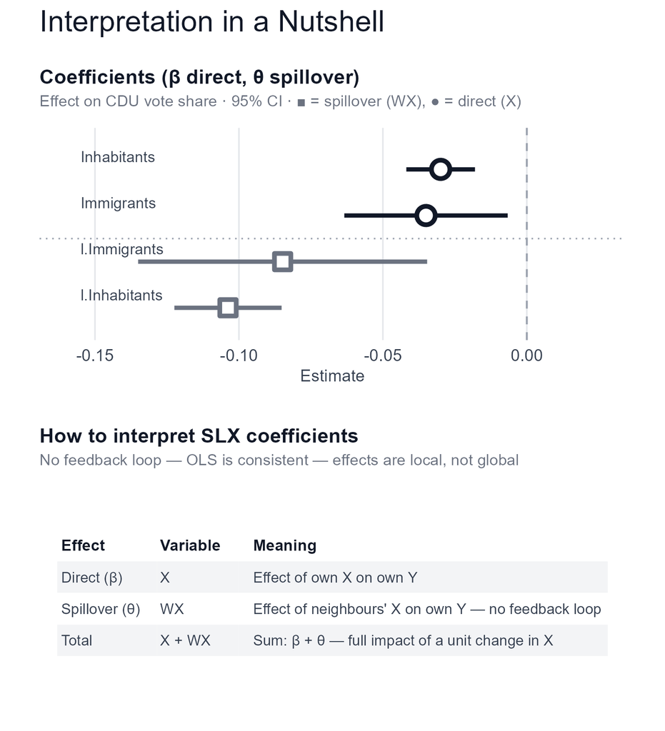

## Spatial Lag Y Model

```r
spatial_lag_y_model <-
  spatialreg::lagsarlm(
    cdu_share ~ immigrant_share + inhabitants,
    data = election_results, listw = queen_W)

summary(spatial_lag_y_model)
```

```
Call:spatialreg::lagsarlm(formula = cdu_share ~ immigrant_share +
    inhabitants, data = election_results, listw = queen_W)

Residuals:
      Min        1Q    Median        3Q       Max
-10.48876  -2.36875  -0.21506   1.93747  23.78484

Type: lag
Coefficients: (asymptotic standard errors)
                  Estimate Std. Error z value  Pr(>|z|)
(Intercept)      9.0224178  1.0909437  8.2703  2.22e-16
immigrant_share -0.0295856  0.0101910 -2.9031  0.003695
inhabitants     -0.0323508  0.0038451 -8.4135 < 2.2e-16

Rho: 0.71173, LR test value: 311.67, p-value: < 2.22e-16
Asymptotic standard error: 0.033348
    z-value: 21.342, p-value: < 2.22e-16
Wald statistic: 455.49, p-value: < 2.22e-16

Log likelihood: -1505.609 for lag model
ML residual variance (sigma squared): 13.319, (sigma: 3.6495)
Number of observations: 543
Number of parameters estimated: 5
AIC: 3021.2, (AIC for lm: 3330.9)
LM test for residual autocorrelation
test value: 29.403, p-value: 5.8781e-08
```

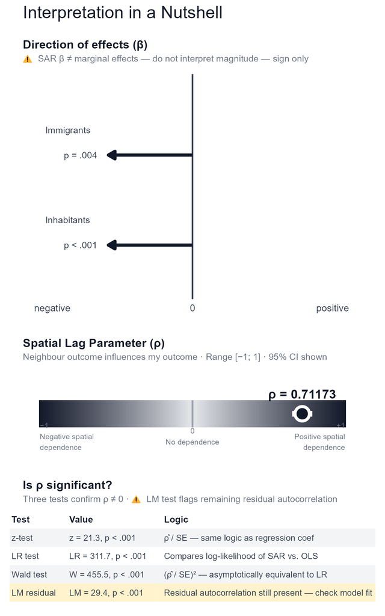

## Comparison: What’s ‘better’?

```r
AIC(spatial_error_model, spatial_lag_x_model, spatial_lag_y_model)
```

```
                    df      AIC
spatial_error_model  5 3062.159
spatial_lag_x_model  6 3187.867
spatial_lag_y_model  5 3021.218
```

```r
spdep::lm.LMtests(linear_regression, queen_W, test = c("LMerr", "LMlag"))
```

```
    Rao's score (a.k.a Lagrange multiplier) diagnostics for spatial dependence

data:
model: lm(formula = cdu_share ~ immigrant_share + inhabitants, data = election_results)
test weights: listw

RSerr = 245.52, df = 1, p-value < 2.2e-16


    Rao's score (a.k.a Lagrange multiplier) diagnostics for spatial dependence

data:
model: lm(formula = cdu_share ~ immigrant_share + inhabitants, data = election_results)
test weights: listw

RSlag = 372.45, df = 1, p-value < 2.2e-16
```

## Comparison: What’s ‘better’?

| Test | Estimate | Points to |
| --- | --- | --- |
| RSerr | 245.5, p < .001 | SEM ($\lambda \neq 0$) |
| RSlag | 372.5, p < .001 | SAR ($\rho \neq 0$) |

RSlag > RSerr → SAR preferred … but the SAR residuals still show autocorrelation (LM = 29.4, p < .001).

Let’s stick to our theory, shall we?

## Of higher importance: interpretation

Unfortunately, in a Spatial Lag Y Model, the spatial parameter $\rho$ only tells us whether the effect is (statistically) significant.

- Remember: these models are endogenous by design
  - We have effects of $y_j$ on $y_i$ and vice versa
  - What a mess

Luckily, there’s a method to decompose the spatial effects into direct, indirect, and total effects: **estimating impacts**

## Impact estimation in `R`

This time, let’s start with the Spatial Lag Y Model:

```r
spatialreg::impacts(spatial_lag_y_model, listw = queen_W)
```

```
Impact measures (lag, exact):
                           Direct    Indirect      Total
immigrant_share dy/dx -0.03408500 -0.06854653 -0.1026315
inhabitants dy/dx     -0.03727076 -0.07495324 -0.1122240
```

Compare it to the ‘simple’ regression output:

```r
coef(spatial_lag_y_model)
```

```
            rho     (Intercept) immigrant_share     inhabitants
     0.71172970      9.02241777     -0.02958562     -0.03235085
```

A **1pp increase** in immigrant share **decreases** CDU vote share **in this unit** by **0.0341pp** (direct), and decreases CDU vote share **in the whole neighbourhood system** by a further **0.0685pp** (indirect).

## Spatial Lag X impacts

```r
spatialreg::impacts(spatial_lag_x_model, listw = queen_W)
```

```
Impact measures (SlX, glht):
                           Direct    Indirect      Total
immigrant_share dy/dx -0.03501709 -0.08481509 -0.1198322
inhabitants dy/dx     -0.02992990 -0.10379397 -0.1337239
```

Compare it to the ‘simple’ regression output:

```r
coef(spatial_lag_x_model)
```

```
        (Intercept)     immigrant_share         inhabitants lag.immigrant_share     lag.inhabitants
        33.42607569         -0.03501709         -0.02992990         -0.08481509         -0.10379397
```

Nothing is really gained.

## If you need p-values and stuff

```r
spatialreg::impacts(spatial_lag_y_model, listw = queen_W, R = 500) |>
  summary(zstats = TRUE, short = TRUE)
```

```
Impact measures (lag, exact):
                           Direct    Indirect      Total
immigrant_share dy/dx -0.03408500 -0.06854653 -0.1026315
inhabitants dy/dx     -0.03727076 -0.07495324 -0.1122240
========================================================
Simulation results ( variance matrix):
========================================================
Simulated standard errors
                          Direct   Indirect      Total
immigrant_share dy/dx 0.01165378 0.02580655 0.03664464
inhabitants dy/dx     0.00422869 0.01213137 0.01443474

Simulated z-values:
                         Direct  Indirect     Total
immigrant_share dy/dx -2.951990 -2.720148 -2.854428
inhabitants dy/dx     -8.869092 -6.308796 -7.900314

Simulated p-values:
                      Direct     Indirect   Total
immigrant_share dy/dx 0.0031573  0.0065253  0.0043114
inhabitants dy/dx     < 2.22e-16 2.8122e-10 2.8866e-15
```

## Exercise: Spatial Regression 💪

🖱 [Click here for the exercise](https://denabel.github.io/BIGSSS_geo_2026/exercises/7_Spatial_Regression.html)

## Outlook

## This workshop

| Day | Time | Title |
| --- | --- | --- |
| June 11 | 10:00-11:30 | Introduction |
| June 11 | 11:30-11:45 | Coffee Break |
| June 11 | 11:45-13:00 | Data Formats |
| June 11 | 13:00-14:00 | Lunch Break |
| June 11 | 14:00-15:30 | Mapping |
| June 11 | 15:30-15:45 | Coffee Break |
| June 11 | 15:45-17:00 | Spatial Wrangling |
| June 12 | 10:00-11:30 | Spatial Wrangling |
| June 12 | 11:30-11:45 | Coffee Break |
| June 12 | 11:45-13:00 | Geocoding, Proximity & Spatial Alignment |
| June 12 | 13:00-14:00 | Lunch Break |
| June 12 | 14:00-15:30 | Spatial Analysis |
| June 12 | 15:30-15:45 | Coffee Break |
| June 12 | 15:45-17:00 | Spatial Econometrics & Outlook |

## What else is out there?

Modelling:

- Geographically Weighted Regression
- Multilevel models with spatial autocorrelation
- Dynamic spatial models (lagged y in both space and time)
- Small area estimation/MRP estimating quantities for areas where surveys have too few observations

## What else is out there?

Causal inference:

- Spatial regression discontinuity design (borders as cutoffs)
- Using geographic features as instruments (distance to historical roads)
- Difference-in-differences with spatial spillovers (account for SUTVA violation)

## What else is out there?

GIS techniques

- Routing & network analysis
- Cluster analysis
- Point pattern analysis
- Areal interpolation and imputaion

## Data Sources

**General note**

- Geospatial data are interdisciplinary
- Amount of data feels unlimited and increases
- Thanks to AI more possibility to extract identifiers

**Some examples**

- More remote sensing/satellite imagery
- Geotagged social media data
- Retrieving place references from unstructured texts
- Mobile survey with gps tracking
- Crowdsourced / citizen science data

[figure not shown]

## Geodata and Spatial Regression Analysis

**30-2 July 2026 On-Site Mannheim**

- [Register online](https://training.gesis.org/?site=pDetails&child=full&pID=0xB1DFA1C064924FF290362BB5D8D70177)
- With Tobias Rüttenauer
- Analyzing spatial research questions
- Various spatial regression techniques

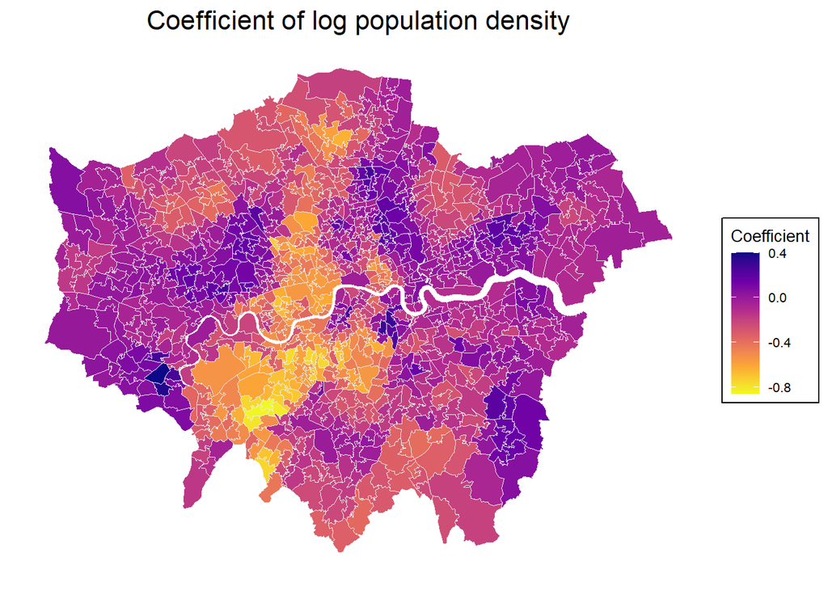

Source:[Geodata_Spatial_Regression](https://ruettenauer.github.io/Geodata_Spatial_Regression/10_other.html)